# Problem Set 2

EC 422: Economic Forecasting | Fall 2026

Author

Aidan Dugan

Published

October 16, 2026

**GitHub repo:** https://github.com/adugan10/ec422_ps2_dugan

## Data

The data include seasonally adjusted monthly unemployment rates for the United States. They also cover Oregon, California, Texas, and New York. The data come from the Federal Reserve Economic Data (FRED) database. Each region’s data is identified by the following series codes: UNRATE for the United States, ORUR for Oregon, CAUR for California, TXUR for Texas, and NYUR for New York. The data series begin in January 1976. Since `tq_get()` wasn’t working for this assignment, I used the `unemp_raw.rds` dataset that Professor Piger provided, which is stored in the project’s `data` folder.

```r
unemp_raw <- read_rds("data/unemp_raw.rds")
head(unemp_raw)
```

```
# A tibble: 6 × 3
  symbol date       price
  <chr>  <date>     <dbl>
1 UNRATE 1976-01-01   7.9
2 UNRATE 1976-02-01   7.7
3 UNRATE 1976-03-01   7.6
4 UNRATE 1976-04-01   7.7
5 UNRATE 1976-05-01   7.4
6 UNRATE 1976-06-01   7.6
```

The saved observations cover January 1976 through August 2026. Each row represents a region in one month. The `price` field in the original data contains the unemployment rate.

## Wrangling

To make the data easier to work with, I started by changing the variable names to be more understandable. I also replaced the FRED codes with the names of the states and the United States. For October 2025, I used the unemployment rate from September 2025, as the instructions said. Next, I calculated the month-to-month changes in unemployment for each region. I made a separate dataset starting from January 2015 and found the average, minimum, and maximum unemployment rates. Finally, I checked which months had the biggest increases and decreases, both with and without 2020, to see how much the pandemic changed the results.

```r
unemp <- unemp_raw |>
  rename(unemployment_rate = price) |>
  mutate(
    region = case_when(
      symbol == "UNRATE" ~ "United States",
      symbol == "ORUR"   ~ "Oregon",
      symbol == "CAUR"   ~ "California",
      symbol == "TXUR"   ~ "Texas",
      symbol == "NYUR"   ~ "New York"
    )
  )

# Represent any skipped month explicitly before filling October 2025.
unemp <- unemp |>
  group_by(region, symbol) |>
  complete(date = seq.Date(min(date), max(date), by = "month")) |>
  ungroup()

unemp <- unemp |>
  arrange(region, date) |>
  group_by(region) |>
  mutate(
    unemployment_rate = replace(
      unemployment_rate,
      date == as.Date("2025-10-01"),
      unemployment_rate[date == as.Date("2025-09-01")]
    )
  ) |>
  ungroup()

unemp <- unemp |>
  arrange(region, date) |>
  group_by(region) |>
  mutate(
    unemployment_rate_change = unemployment_rate - lag(unemployment_rate)
  ) |>
  ungroup()

unemp_recent <- unemp |>
  filter(date >= as.Date("2015-01-01"))

unemp_summary <- unemp |>
  group_by(region) |>
  summarize(
    mean_rate = mean(unemployment_rate, na.rm = TRUE),
    min_rate = min(unemployment_rate, na.rm = TRUE),
    max_rate = max(unemployment_rate, na.rm = TRUE),
    .groups = "drop"
  )

unemp_recent_summary <- unemp_recent |>
  group_by(region) |>
  summarize(
    mean_rate = mean(unemployment_rate, na.rm = TRUE),
    min_rate = min(unemployment_rate, na.rm = TRUE),
    max_rate = max(unemployment_rate, na.rm = TRUE),
    .groups = "drop"
  )

unemp_top_increases <- unemp |>
  filter(!is.na(unemployment_rate_change)) |>
  slice_max(unemployment_rate_change, n = 5, with_ties = TRUE)

unemp_top_decreases <- unemp |>
  filter(!is.na(unemployment_rate_change)) |>
  slice_min(unemployment_rate_change, n = 5, with_ties = TRUE)

unemp_no_covid <- unemp |>
  filter(format(date, "%Y") != "2020")

unemp_top_increases_no_covid <- unemp_no_covid |>
  filter(!is.na(unemployment_rate_change)) |>
  slice_max(unemployment_rate_change, n = 5, with_ties = TRUE) |>
  select(region, date, unemployment_rate_change, unemployment_rate)

unemp_top_decreases_no_covid <- unemp_no_covid |>
  filter(!is.na(unemployment_rate_change)) |>
  slice_min(unemployment_rate_change, n = 5, with_ties = TRUE) |>
  select(region, date, unemployment_rate_change, unemployment_rate)
```

### Table 1. Full-sample unemployment rate summary

This table shows the mean, minimum, and maximum unemployment rates for each region across all available months in the saved data.

Full-sample unemployment rates (percent)

| region | mean_rate | min_rate | max_rate |
| --- | --- | --- | --- |
| California | 7.08 | 3.8 | 16.1 |
| New York | 6.35 | 3.8 | 16.7 |
| Oregon | 6.66 | 3.4 | 13.7 |
| Texas | 5.85 | 3.4 | 12.8 |
| United States | 6.05 | 3.4 | 14.8 |

### Table 2. Unemployment rate summary since January 2015

This table uses only months from January 2015 onward.

Unemployment rates since January 2015 (percent)

| region | mean_rate | min_rate | max_rate |
| --- | --- | --- | --- |
| California | 5.64 | 3.8 | 16.1 |
| New York | 5.11 | 3.8 | 16.7 |
| Oregon | 4.75 | 3.4 | 13.7 |
| Texas | 4.58 | 3.4 | 12.8 |
| United States | 4.62 | 3.4 | 14.8 |

### Table 3. Largest monthly increases excluding 2020

This table lists the five largest month-over-month unemployment rate increases outside 2020, including any tied values. Changes are measured in percentage points.

Largest monthly increases, excluding 2020

| region | date | unemployment_rate_change | unemployment_rate |
| --- | --- | --- | --- |
| Texas | 2009-05-01 | 1.1 | 7.6 |
| Oregon | 2008-12-01 | 0.7 | 8.9 |
| Oregon | 2008-11-01 | 0.7 | 8.2 |
| Oregon | 2009-01-01 | 0.7 | 9.6 |
| Oregon | 1980-03-01 | 0.6 | 7.4 |
| United States | 1980-04-01 | 0.6 | 6.9 |

### Table 4. Largest monthly decreases excluding 2020

This table lists the five largest decreases outside 2020, including any ties.

Largest monthly decreases, excluding 2020

| region | date | unemployment_rate_change | unemployment_rate |
| --- | --- | --- | --- |
| United States | 1983-07-01 | -0.7 | 9.4 |
| New York | 2021-09-01 | -0.6 | 6.2 |
| Oregon | 1977-05-01 | -0.5 | 7.8 |
| California | 2021-07-01 | -0.5 | 7.4 |
| California | 2021-09-01 | -0.5 | 6.5 |
| New York | 2021-07-01 | -0.5 | 7.0 |
| United States | 2010-12-01 | -0.5 | 9.3 |
| United States | 2014-04-01 | -0.5 | 6.2 |
| United States | 2021-07-01 | -0.5 | 5.4 |

## Visualization

### Figure 1. Unemployment rates over time

This graph shows the unemployment rates for all five regions at once. I see that the rates usually rise and fall together, but some states have higher unemployment than others. The most noticeable change is in 2020, when unemployment went up quickly in every region.

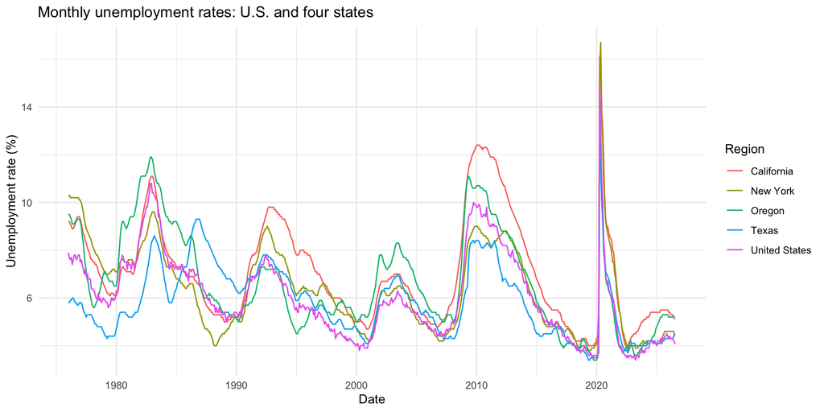

### Figure 2. Unemployment rates in individual panels

For this graph I’ve split each region out so it’s easier to see the trends in unemployment in each region without the lines all overlapping. California had fairly high unemployment around 2010 and then all five regions saw a very sharp spike in 2020. Having the graphs split up makes the differences much easier to compare.

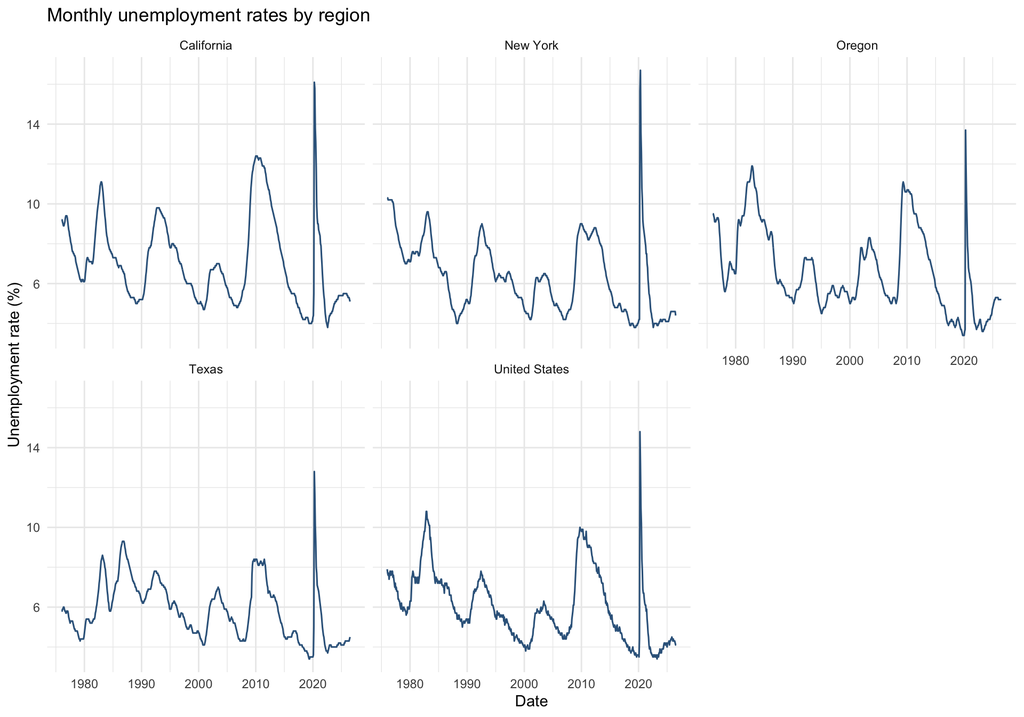

### Figure 3. Mean unemployment rates by region

This bar chart compares the average unemployment rates for all five regions during the entire period. California had the highest average at 7.08%, and Texas had the lowest at 5.85%. I ordered the bars from lowest to highest to make the differences easier to see.

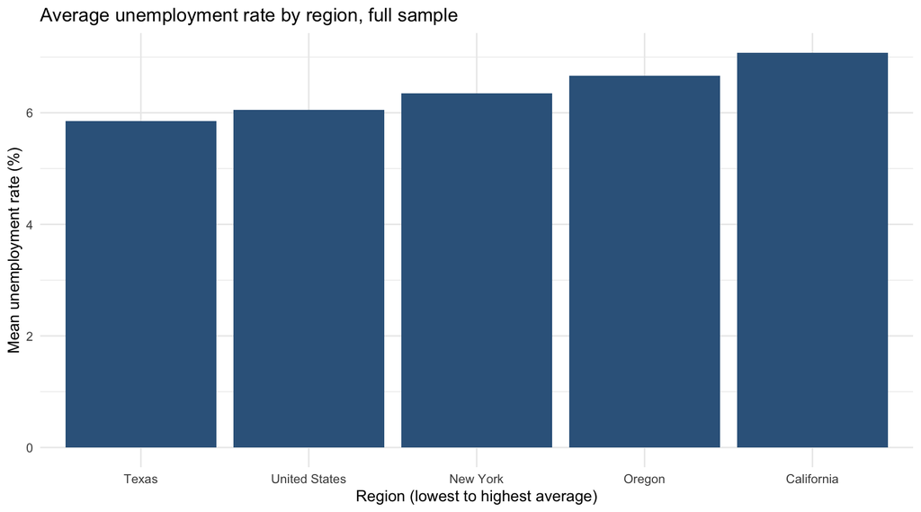

### Figure 4. Size of monthly changes by region

For my last graph, I used boxplots to look at month-to-month changes in unemployment in each region. I’ve used the absolute change (so it doesn’t matter whether unemployment goes up or down, it just measures the size of the change). Most months had fairly small changes but there were some months with much larger changes. I chose this graph because it makes it easier to compare how much unemployment changes from month to month across the different regions.

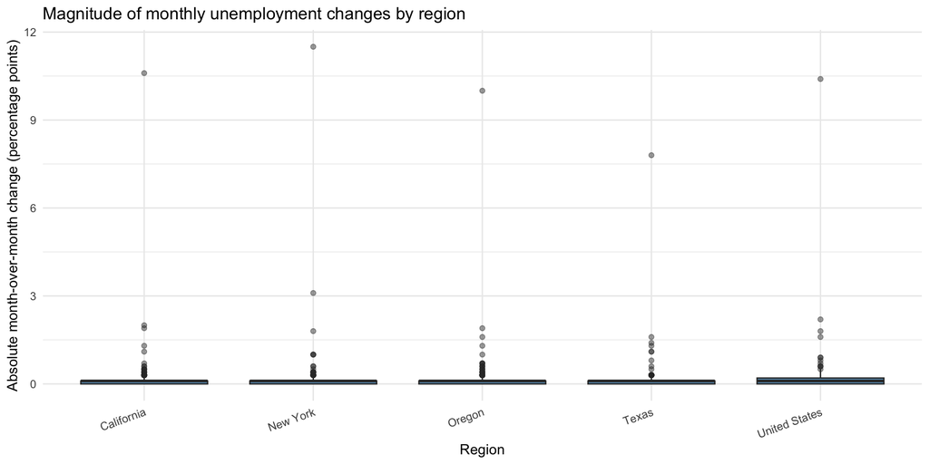

## Reflection

This assignment helped me get more comfortable using R to work with data. Using the provided data file made it easier to focus on organizing the data and creating the tables and graphs. One thing I had to pay more attention to was making sure the dates were in the right order when calculating monthly changes. I also thought it was interesting to see how excluding 2020 affected the results. Overall, I have a better understanding of how RStudio, Quarto, and GitHub work together.